# Multinomial Logistic Regression in R, Stata and SAS

Yunsun Lee, Hui Xu, Su I Iao (Group 12)

November 27, 2018

## Algorithm Description

The purpose of this tutorial is to demonstrate multinomial logistic regression in R, Stata and SAS. The following is a brief summary of the [multinomial logistic regression](https://en.wikipedia.org/wiki/Multinomial_logistic_regression).

## Importance of the multinomial logistic regression model

Multinomial logistic regression is an extension of binary logistic regression that dependent variables have more than two categories. The model is used to predict the probabilities of the different outcomes. It is important and useful since we can predict and then control the outcome by some degrees.

## Data Summary

In this tutorial, we will work on the *Iris flower data set*. This famout Fisher’s Iris data set is a multivariate data set introduced by the British statistician and biologist Ronald Fisher in his 1936 paper *“The use of multiple measurements in taxonomic problems as an example of linear discriminant analysis.”* It is sometimes called Anderson’s Iris data set because Edgar Anderson collected the data to quantify the morphologic variation of Iris flowers of three related species.

The data set consists of 50 samples from each of three species of Iris(Iris setosa, Iris virginica and Iris versicolor). Four features were measured from each sample : the length and the width of the sepals and petals, in centimeters. Based on the combination of these four features, Fisher developed a linear discriminant model to distinguish the species from each other. Based on Fisher’s linear discriminant model, this data set became a typical test case for many statistical classification techniques.

Below are pictures of three species of Iris flowers.

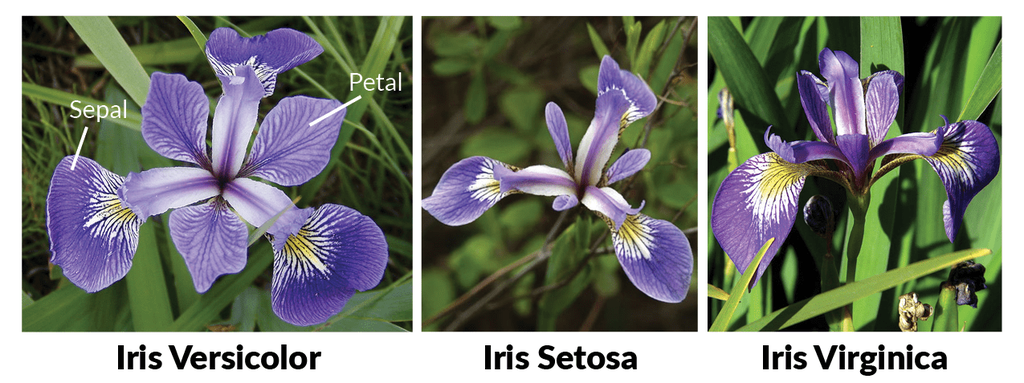

We can obtain Iris data from [here](https://www.kaggle.com/vvenanccio/irisflowers). Also, this dataset is already contained in R. Therefore just by loading it, Iris data is available to use in R. The dataset contains a set of 150 records under five attributes - petal length, petal width, sepal length, sepal width and species. Description of variables are as followed.

| Variables | Description | Data type |
| --- | --- | --- |
| Sepal.Length | sepal length in centimeters | positive real number |
| Sepal.Width | sepal width in centimeters | positive real number |
| Petal.Length | petal length in centimeters | positive real number |
| petal.Width | petal width in centimeters | positive real number |
| Species | species | categorical(setosa/versicolour/virginica) |

## Our Model

Our task is to model two equations below using R, Stata and SAS with Iris data set.

$$ln\frac{Pr(Species = setosa)}{Pr(Species = virginica)} = \beta_{10} + \beta_{11}\cdot Sepal.Length + \beta_{12}\cdot Sepal.Width + \beta_{13}\cdot Petal.Length + \beta_{14}\cdot Petal.Width X_{i}$$
$$ln\frac{Pr(Species = versicolor)}{Pr(Species = virginica)} = \beta_{20} + \beta_{21}\cdot Sepal.Length + \beta_{22}\cdot Sepal.Width + \beta_{23}\cdot Petal.Length + \beta_{24}\cdot Petal.Width X_{i}$$

## R

### Load the data

First, we need to load iris data into R. It is possible to download the data from [here](https://www.kaggle.com/vvenanccio/irisflowers), but iris dataset is already contained in R. Therefore, just by loading it, iris data will be available and can be used.

```r
data(iris)
```

### Description of the data

This is what the first 6 rows look like.

```r
head(iris)
```

```
##   Sepal.Length Sepal.Width Petal.Length Petal.Width Species
## 1          5.1         3.5          1.4         0.2  setosa
## 2          4.9         3.0          1.4         0.2  setosa
## 3          4.7         3.2          1.3         0.2  setosa
## 4          4.6         3.1          1.5         0.2  setosa
## 5          5.0         3.6          1.4         0.2  setosa
## 6          5.4         3.9          1.7         0.4  setosa
```

We can get basic descriptives for the entire data set by using summary.

```r
summary(iris)
```

```
##   Sepal.Length    Sepal.Width     Petal.Length    Petal.Width
##  Min.   :4.300   Min.   :2.000   Min.   :1.000   Min.   :0.100
##  1st Qu.:5.100   1st Qu.:2.800   1st Qu.:1.600   1st Qu.:0.300
##  Median :5.800   Median :3.000   Median :4.350   Median :1.300
##  Mean   :5.843   Mean   :3.057   Mean   :3.758   Mean   :1.199
##  3rd Qu.:6.400   3rd Qu.:3.300   3rd Qu.:5.100   3rd Qu.:1.800
##  Max.   :7.900   Max.   :4.400   Max.   :6.900   Max.   :2.500
##        Species
##  setosa    :50
##  versicolor:50
##  virginica :50
##
##
##
```

### Seperate the data into training set and testing set

We partition the data into two parts - a training set consisting of the first 40 observations for each species and a testing set of the remaining 10 observations for each species. We use a training set to build and estimate the model and a testing set to see how well the model does on new data not used in the constuction of the model.

```r
train_1 = iris[1:40,]; train_2 = iris[51:90,]; train_3 = iris[101:140,]
train = rbind(train_1,train_2); train = rbind(train, train_3)
test_1 = iris[41:50,]; test_2 = iris[91:100,]; test_3 = iris[141:150,]
test = rbind(test_1,test_2); test = rbind(test, test_3)
```

### Build the multinomial logistic regression model using the train set

Below we use the *multinorm* function from the nnet package to estimate a multinomial logistic regression model. Before running our model, we choose the level of our outcome that we wish to use our baseline and specify this in the *relevel* function. We pick “virginica” as our baseline. Then, we run our model using *multinom*. The nnet package does not include p-value calculation for the regression coefficients, so we calculate p-values using Wald tests(here z-tests).

```r
library(nnet)
train$species2 = relevel(train$Species, ref = "virginica")
model = multinom(species2 ~ Sepal.Length + Sepal.Width +
                    Petal.Length + Petal.Width , data = train)
summary(model)
```

```
## Call:
## multinom(formula = species2 ~ Sepal.Length + Sepal.Width + Petal.Length +
##     Petal.Width, data = train)
##
## Coefficients:
##            (Intercept) Sepal.Length Sepal.Width Petal.Length Petal.Width
## setosa         5.28918    10.978504   16.793690   -23.702171   -18.17830
## versicolor    41.55886     2.416804    6.591888    -9.215024   -17.93605
##
## Std. Errors:
##            (Intercept) Sepal.Length Sepal.Width Petal.Length Petal.Width
## setosa        18.62301    18.505809   57.575716    75.538379   40.361463
## versicolor    25.43734     2.385384    4.460913     4.693846    9.756292
##
## Residual Deviance: 11.8463
## AIC: 31.8463
```

```r
z = summary(model)$coefficients/summary(model)$standard.errors
z
```

```
##            (Intercept) Sepal.Length Sepal.Width Petal.Length Petal.Width
## setosa       0.2840132    0.5932464   0.2916801   -0.3137765  -0.4503876
## versicolor   1.6337740    1.0131715   1.4776994   -1.9632137  -1.8384089
```

```r
p = (1 - pnorm(abs(z), 0, 1)) * 2
p
```

```
##            (Intercept) Sepal.Length Sepal.Width Petal.Length Petal.Width
## setosa       0.7764003    0.5530163   0.7705312   0.75369076  0.65243097
## versicolor   0.1023063    0.3109783   0.1394882   0.04962134  0.06600218
```

The model summary output has a block of coefficients and a block of standard errors. Each of these blocks has one row of values corresponding to a model equation. Two models are tested in this multinomial regression, one comparing membership to setosa versus virginica and one comparing membership to versicolor versus virginica. They correspond to the two equations below:

$$\begin{split} ln\frac{Pr(Species = setosa)}{Pr(Species = virginica)} = & 5.28918 +10.978504\times Sepal.Length + 16.793690\times Sepal.Width\\ & -23.702171 \times Petal.Length -18.17830\times Petal.Width \end{split}$$
$$\begin{split} ln\frac{Pr(Species = versicolor)}{Pr(Species = virginica)} = & 41.55886 + 2.416804\times Sepal.Length + 6.591888\times Sepal.Width\\ & -9.215024\times Petal.Length -17.93605\times Petal.Width \end{split}$$

Through the p-values, we can see all of the coefficients of the first model(setosa vs. virginica) is not significant while some of the coefficients of the second model(versicolor vs. virginica) is significant. It means we may need to combine setosa and virginica. Then the model becomes a binomial logistic regression model.

### Test the accuracy of model using the test set

Now we can test our model using a test set data. We compute the accuracy rate. The result is 1. Good performance!

```r
library(data.table)
a = predict(model, newdata =test, "probs")
a = data.table(a)
b = rep(1,30)
b[which(a$versicolor == apply(a, 1, max))]=2
b[which(a$virginica == apply(a, 1, max))]=3
c = c(rep(1,10), rep(2,10), rep(3,10))
accuracy = sum(b==c)/30
accuracy
```

```
## [1] 1
```

## SAS

### Read the data into SAS

We use proc import to import the dataset.

```sas
FILENAME REFFILE '/Iris.csv';

PROC IMPORT DATAFILE=REFFILE
    DBMS=CSV
    OUT=work.import;
    GETNAMES=YES;
RUN;
```

### Description of Data

We get basic descriptives for the entire data set by using proc summary.

```sas
proc summary data=work.import min q1 mean q3 max std n;
var Sepal_Length Sepal_Width Petal_Length Petal_Width;
by Species;
output out = iris_summary;

proc print data = iris_summary;
title 'Summary of Iris data set';
run;
```

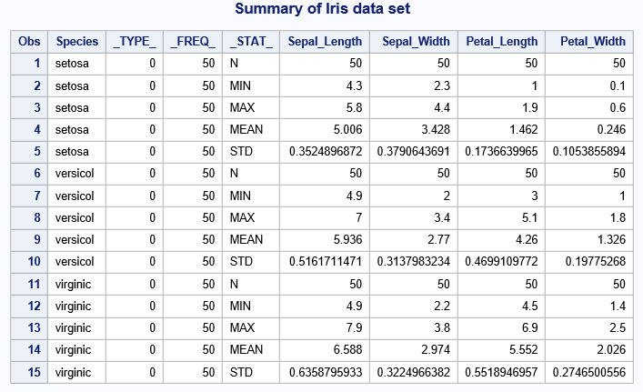

### Separate the data into train set and test set

```sas
data train;
set work.import;
if _N_ in (1:40, 51:90, 101:140) then output;
run;

data test;
set work.import;
if _N_ in (41:50, 91:100, 141:150) then output;
run;
```

### Build the multinomial logistic regression model by train set

```sas
proc logistic data = train;
class species (ref = "virginic");
model species =  Sepal_Length Sepal_Width Petal_Length Petal_Width / link = glogit;
score data=test out=valpred;
title 'Multinomial Logistic Regression Model';
run;
```

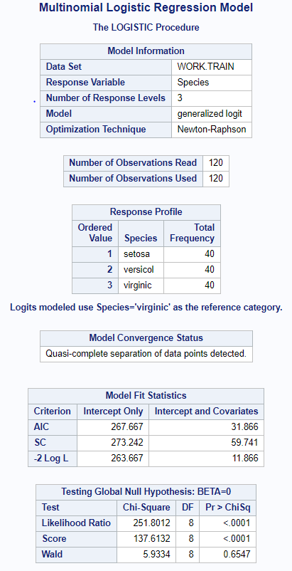

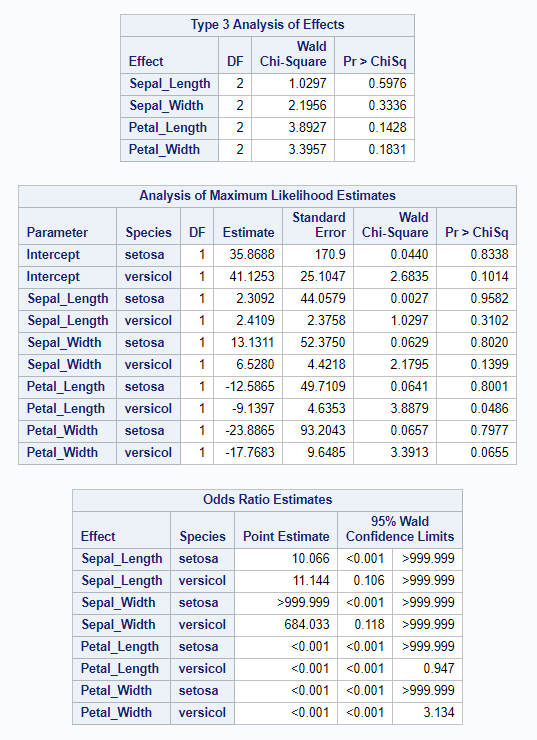

In the output above, the likelihood ratio chi-square of 251.8012 with a p-value < 0.0001 tells us that our model as a whole fits significantly better than an empty model (i.e., a model with no predictors)

Two models are tested in this multinomial regression, one comparing membership to setosa versus virginic and one comparing membership to versicolor versus virginic. They correspond to the two equations below:

$$\begin{split}
ln\frac{Pr(Species = setosa)}{Pr(Species = virginica)} = & 35.8688 +2.3092\times Sepal.Length + 13.1311\times Sepal.Width\\ &- 12.5865\times Petal.Length - 23.8865\times Petal.Width
\end{split}$$
$$\begin{split}
ln\frac{Pr(Species = versicolor)}{Pr(Species = virginica)} = & 41.1253 +2.4109\times Sepal.Length + 6.5280\times Sepal.Width\\ &- 9.1397\times Petal.Length - 17.7683\times Petal.Width
\end{split}$$

### Test the accuracy of model by test set

Based on the fitted model, now we can predict the each species probability of the testing data set. Each predicted species probability is between 0 and 1, hence we regard the highest probability one as its species.

```sas
data prediction;
 set valpred;
 species_pre = 0;
 species_ori = 0;
 accuracy = 1;
 if species = 'setosa' then species_ori=1;
 if species = 'versicol' then species_ori=2;
 if species = 'virginic' then species_ori=3;
 if P_setosa > P_versicol and p_setosa > P_virginic then species_pre=1;
 if P_versicol > P_setosa and P_versicol > P_virginic then species_pre=2;
 if P_virginic > P_setosa and P_virginic > P_versicol then species_pre=3;
 if species_ori > species_pre then delete;
 if species_ori < species_pre then delete;
 keep species accuracy;

proc summary data=prediction;
output out=accuracy
sum(accuracy) = accuracy;

data final;
set accuracy;
accuracy = accuracy/30;

proc print data=final;
title 'Test the Accuracy by Test Set';
run;
```

[output not shown]

## Stata

### Load the data

We start with loading the data and then present the first 5 rows.

```stata
clear all
* Loading the data
import delimited iris.csv
list in 1/5
```

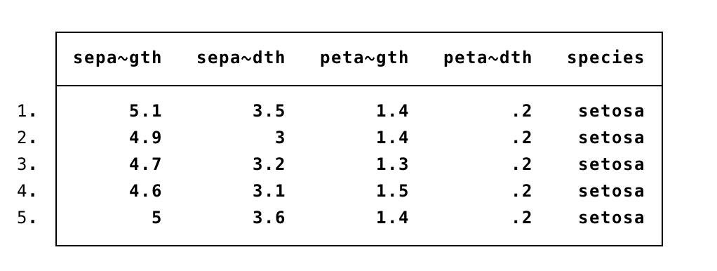

### Description of Data

Then we get the basic description for both predictors and respones.

```stata
* Discription of Data
summarize sepal_length sepal_width petal_length petal_width
```

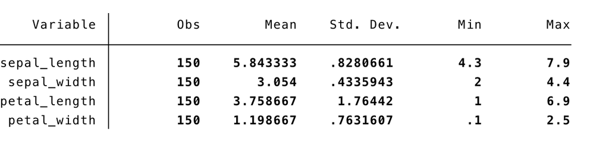

```stata
tab species
```

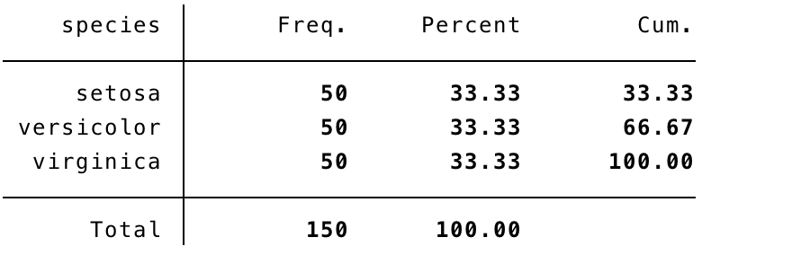

### Separate the data into train set and test set

We partition the data into two parts - a training set consisting of the first 40 observations for each species and a testing set of the remaining 10 observations for each species. We use a training set to build and estimate the model and a testing set to see how well the model does on new data not used in the constuction of the model.

```stata
* Separate the data into train set and test set
gene seqnum=_n
generate training = 1 if seqnum <= 40 | seqnum >= 51 & seqnum <= 90 | seqnum >= 101 & seqnum <= 140
replace training = 0 if training == .
```

### Build the multinomial logistic regression model by train set

Below we use the mlogit command to estimate a multinomial logistic regression model. In the model, we choose to pick virginica as the baseline category and then fitting the model.

```stata
* In the model, we choose to pick virginica as the baseline category
* Since mlogit only accepts numeric arguments, thus encoding string into numeric
encode species, generate(new_species)
mlogit new_species sepal_length sepal_width petal_length petal_width if training == 1, base(3)
```

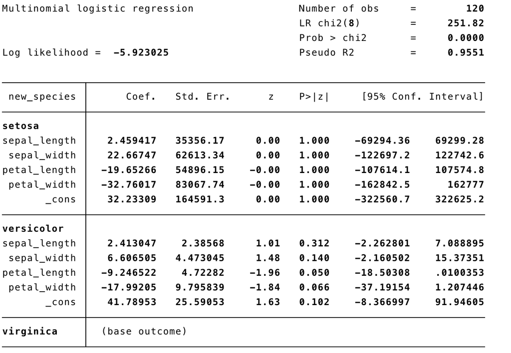

From the output, we can notice the likelihood ratio chi-square is 251.82 with p-value 0, which means our model fits significantly better than model with no predictors.

From the regression coefficient, we notice length and width of petal are negatively related with relatively log odds in both case; while length and width of sepal is positively related with log odds in both case. For example, a one-unit increase in the variable sepal_length is associated with a 2.46 increase in the relative log odds of being in setosa v.s. virginica.

#### Relative Risk

Relative Risk is defined as the ratio of probability of one outcome category over the probability of baseline category. In this case, the relative risk in setosa v.s. virginica is the ratio of probability of setosa over the probability of virginica. Here we can use the mlogit, rrr command to get the regression results in the form of relative risk ratios.

```stata
mlogit, rrr
```

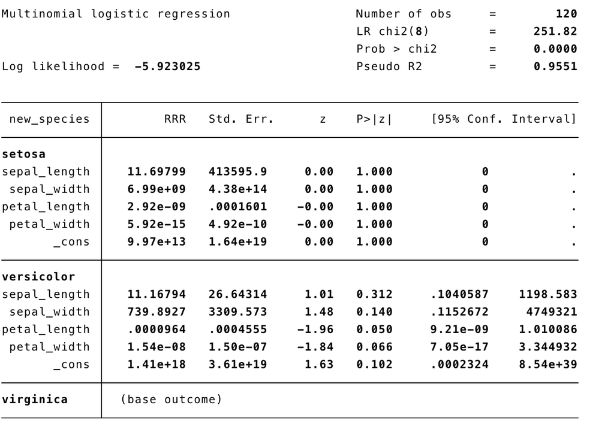

In fact, the relative risk in the table can be obtained by exponentiating the regression coefficients above. For instance, the ralative risk for the on-unit increase in the variable sepal_length is 11.698 insetosa v.s. virginica, which can be obtained by exp(2.459417) from the output of regression coefficients.

### Test the accuracy of model by test set

```stata
* Get the Prediction by using test dataset
keep if training == 0
predict setosa
predict versicolor, equation(versicolor)
predict virginica, equation(virginica)
* Encode the origin species to numbers
gen species_ori = 1 if species == "setosa"
replace species_ori = 2 if species == "versicolor"
replace species_ori = 3 if species == "virginica"
* Consider the catogory of highest probability as the last predict model
gen species_pre=1 if setosa > versicolor & setosa > virginica
replace species_pre=2 if versicolor > setosa & versicolor > virginica
replace species_pre=3 if virginica > setosa & virginica > versicolor
* Check the difference between prediction and the original category
display species_pre - species_ori
```

[output not shown]

## Output summary

The results summary are as followed. The coefficients for predictors from 3 language examples are different. Interestingly, the coefficients in the model comparing virginica with setosa are quite different while the coefficients in the model comparing virginica with versicolor are pretty similar with some errors.

Setosa

|  | intercept | Sepal.Length | Sepal.Width | Petal.Length | petal.Width |
| --- | --- | --- | --- | --- | --- |
| R | 5.29 | 10.98 | 16.79 | -23.70 | -18.18 |
| SAS | 35.87 | 2.31 | 13.13 | -12.59 | -23.89 |
| STATA | 32.23 | 2.46 | 22.67 | -19.65 | -32.76 |

Versicolor

|  | intercept | Sepal.Length | Sepal.Width | Petal.Length | petal.Width |
| --- | --- | --- | --- | --- | --- |
| R | 41.56 | 2.42 | 6.59 | -9.22 | -17.94 |
| SAS | 41.13 | 2.41 | 6.53 | -9.14 | -17.77 |
| STATA | 41.79 | 2.41 | 6.61 | -9.25 | -17.99 |

It may be because the coefficients of the former are not significant at all while some of the coefficients of the latter are significant. We will figure it out more later.

p-value calculated in R

|  | intercept | Sepal.Length | Sepal.Width | Petal.Length | petal.Width |
| --- | --- | --- | --- | --- | --- |
| Setosa | 0.7764003 | 0.5530163 | 0.7705312 | 0.75369076 | 0.65243097 |
| versicolor | 0.1023063 | 0.3109783 | 0.1394882 | 0.04962134 | 0.06600218 |

## References

- iris data description : https://en.wikipedia.org/wiki/Iris_flower_data_set
- picture of iris : http://www.lac.inpe.br/~rafael.santos/Docs/R/CAP394/WholeStory-Iris.html
- multinomial logistic regression in R : https://stats.idre.ucla.edu/r/dae/multinomial-logistic-regression/
- multinomial logistic regression in SAS : https://stats.idre.ucla.edu/sas/dae/multinomiallogistic-regression/
- multinomial logistic regression in STATA : https://stats.idre.ucla.edu/stata/dae/multinomiallogistic-regression/